# Child Mortality by Race Over Time

Amanuel

October 31, 2017

INFANT MORTALITY DATA - DEATH RATES BY RACE OVER TIME First we need to download and place our datasets in a directory

Set working directory as the root directory (where datasets are saved) in knitr::opts_chunk$set(root.dir=‘/DataSetFolder’)

```r
#make a list that contains your data sets
# provide the right path
#(YourWorkingDirectory or just use "getwd()")
mortalityData_list <- list.files(path=getwd(), pattern="*.txt",
                       full.names = TRUE)
```

The lapply, sapply, tapply… family of functions are very handy in performing the same thing to several variables or datasets etc.

In our case, data sets are .txt files and tab delimited, we will use lapply on the data list created to read in each of them

```r
datalist <- lapply(mortalityData_list, read.delim)
```

```r
#DATA CLEANING
#the "Death.Rate" column in those data sets has "(Unreliable)"
# in some of the cells, we need to remove it, so
#this replaces "(Unreliable)" with nothing.
mortalityData <- lapply(datalist, function(i)
   transform(i, Death.Rate = gsub("(Unreliable)", "",
                                  fixed = TRUE, Death.Rate)))
#fixed=TRUE so '(' & ')' are removed too

#drops first columns
mortalityData <- lapply(mortalityData, function(x) x[, -1])

#in doing so, I noticed that it created several 'NA's,
# so we have to removes "NA"
mortalityData <- lapply(mortalityData, function(y) y[rowSums(is.na(y)) == 0, ])

#I can transform some of the columns to factor or numeric ...
mortalityData <- lapply(mortalityData, transform, Death.Rate=as.numeric(Death.Rate),
                  State=as.factor(State), Race=as.factor(Race),
                State.Code=as.factor(State.Code))
```

```r
#We need to include a time variable for each of the 8 datasets
#So, we create a list of years & populate a column with specific year

years <- list(2007, 2008, 2009, 2010, 2011, 2012, 2013, 2014)

#add year indicator to each data frame in the list
for( i in seq_along(mortalityData)){
  mortalityData[[i]]$year <- rep(years[i], nrow(mortalityData[[i]]))
}

#combine data frames to one long form if you like
#but one can also operate on each of the datasets without row-binding
mortalityData_long <- as.data.frame(do.call("rbind", mortalityData))

#I just realized that the "year" variable I added above
# is a list and ggplot doesn't know
# what to dow with it, so change it using "unnest" function from tidyr package

mortalityData_long <- unnest(mortalityData_long, year)

mortalityData_long[,3] <- as.factor(mortalityData_long$Race)
mortalityData_long[,8] <- as.factor(mortalityData_long$year) #Just so all the years appear on horiz axis
```

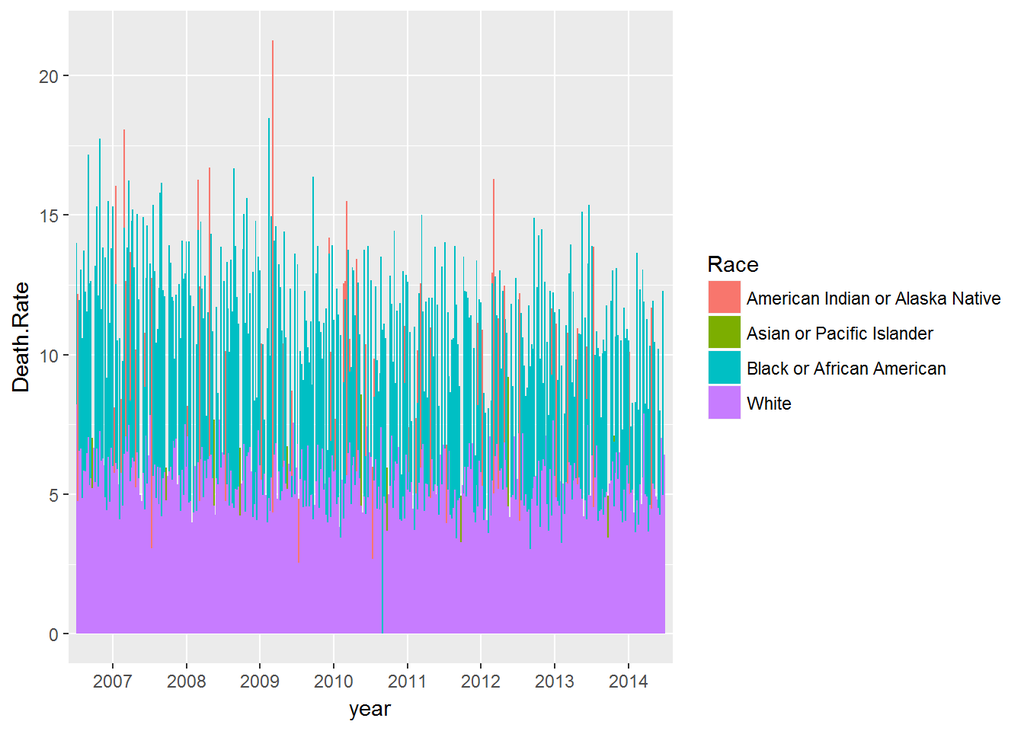

```r
#Plots

childMortality_plot1 <- ggplot(data=mortalityData_long,
                     aes(x=year , y=Death.Rate, group=State,
                         fill=Race, na.rm=TRUE)) +
  geom_bar(stat="identity", width = 1, position=position_dodge())

#Reveal plot
childMortality_plot1
```

But we can look at the data nationally. To do that, we quickly compute new variables as follows: Let’s create 3 variables on the fly and we will use them for ggploting. This will render the “State” variable useless. (By race & by year nationally is what I’m after)

```r
#using the 'pipe' %>% operator
mortalityData_long <- mortalityData_long %>% group_by(year, Race) %>%
  mutate(tot_Deaths = sum(Deaths), tot_Births=sum(Births),
         Child_Mortality_Rates=(round(tot_Deaths/tot_Births*1000, 1)))
```

The new plot clearly shows higher child mortality rates for Amrican Indian/Alaska Natives & Black/African American. Asian/Pacific Islander has the lowest. Mortality rates for Whites are probably higher than mortality rates for Hispanic/Latinos. The bars for the White group includes Hispanic/Latino ethnicity that identify as White and there are some indications that child mortality rates are lower for Hispanics/Latinos.

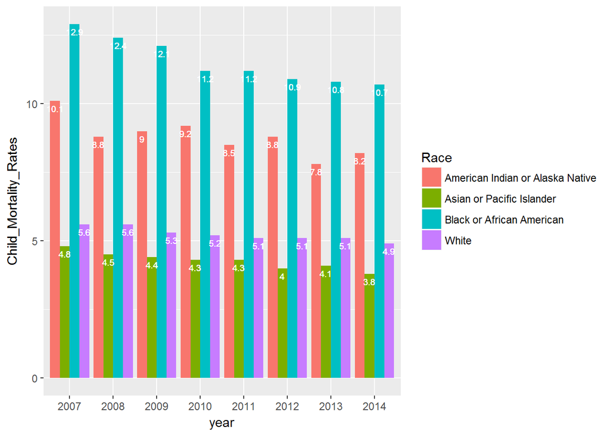

```r
#New Plot (childMortality_plot2)
childMortality_plot2 <- ggplot(data=mortalityData_long,
                     aes(x=year , y=Child_Mortality_Rates, group=Race,
                         fill=Race, na.rm=TRUE)) +
  geom_bar(stat='identity', position=position_dodge()) +
geom_text(aes(label=Child_Mortality_Rates), vjust=1.6, color='white',
          position=position_dodge(0.9), size=2.5)


#Reveal new plot
childMortality_plot2
```